# IEAP-Series01-Python: Download and plot an ECG signal

01 September 2026, 14:53:28

**Table of contents**

- 1. The goal of series 01
- 2. Create a project on your own machine
  - 2.1. Manually get the data on your computer
  - 2.2. Create a minimal ECG data processing pipeline
  - 2.3. Create a readme file for your project
  - 2.4. Checks
- 3. Share your repository on GitHub
  - 3.1. Push your project to GitHub
  - 3.2. Check
- 4. Start coding your ECG data processing pipeline using Git branches
  - 4.1. Make clear what are the steps of your analysis
  - 4.2. Create a new branch
  - 4.3. Load the data
  - 4.4. Plot the raw ECG data
  - 4.5. Merge the branch into the main branch
  - 4.6. What you have learned up to now
- 5. Advanced ECG data processing pipeline
  - 5.1. Rescale the ECG data to standard units
    - 5.1.1. Conversion to mV
    - 5.1.2. Conversion to seconds
  - 5.2. Plot the ECG data
  - 5.3. Check the plot
- 6. Improve readability
  - 6.1. Why? To make your code easier to read and understand.
  - 6.2. How? Using Git branches.
- 7. Make a plot that resembles what you get with real ECG systems

# 1. The goal of series 01

The goal of this series is to analyze physiological data (here an ECG signal) using Python and Git.

Your mission is to **display the ECG signal**:

- You will do this step by step, improving the code as you go, and Git will help you tracking the changes with the commit history.
- You will start with a preliminary version of your code, which you will improve to make it easier to read and maintain, using Git branches.

Your mission is simple, but you will carry it out following best practices, which are essential for writing reproducible data analysis code.

# 2. Create a project on your own machine

Your first mission is to create a new repository (directory) on your local machine, to contain your Python code for the series 01.

You goal is to arrive at the following directory structure:

```
M1-Projects/
├── ... other course projects ...
└── Python-R-Git/
    ├── Series00
    └── Series01
        ├── Series01-RStudio
        └── Series01-python
            ├── readme.md               # main readme file
            ├── data                    # data folder
            │   └── ECGu.txt            # data file
            └── Series01-python.ipynb   # notebook file, to run analyses
```

## 2.1. Manually get the data on your computer

Download the file: http://denis.mottet.free.fr/M2R/WORK/DATA/ECGu.txt

- Store this file at the right place and with the right file name.
  - Google: “display filename extensions with Windows”.
- Where is this file? What's the path to it?
  - Google: “show file path in Windows Explorer” or “show file path in Mac Finder”.

## 2.2. Create a minimal ECG data processing pipeline

The very first step is to **load the data**. You will do this in a Jupyter notebook using VS Code.

- Create a Jupyter notebook at the right place and with the right file name.
- Add a first code cell to load the data and display it.
- Check that the data is loaded correctly: are the numbers the same as in the original file?
- If yes, this is enough for now. You will improve this code in the next steps.

## 2.3. Create a readme file for your project

All GitHub repositories should have a readme file. You will create one for your project, and you will write in it the purpose of your project.

You will do this in a markdown file using VS Code.

- Create a markdown file at the right place and with the right file name.
- Add the **minimum information** to explain the purpose of your project. Do you think this is understandable for someone else (ask your classmates)?  
  Minimum information means that you should answer the following questions, but make your answers short, clear and descriptive:
  - does it have a title?
  - does it have a description?
  - does it need more information?  
    Maybe not for now, but you can add more information later if you want to. For example, you could add a description of the data, or a description of the analysis steps.

Example of a possible (minimum) content for the readme file:

```
# Series01-python: ECG signal analysis using Python

This project analyzes ECG signals using Python. It is part of Series01 of the Python-R-Git course of the Master's program on Engineering and Ergonomics of Physical Activity at the University of Montpellier.
```

## 2.4. Checks

- Is the data saved at the right place?
- Is the Jupyter notebook saved at the right place?
- Is the readme file saved at the right place?
- Is the data loaded correctly in the notebook?
- Is the readme file understandable for someone else?

If yes, you are done with the first steps of creating a new project **on your computer**.

The next step is to **push your project to GitHub**.

# 3. Share your repository on GitHub

As you have a local repository, you simply need to share it on GitHub using GitHub Desktop.

- In GitHub Desktop, click on the menu `File` > `New repository...` and follow the instructions to create a new repository on GitHub.
  - The name of the repository should be the same as the name of your local repository, namely **Series01-python**.
  - The description of the repository should be the same as the description in your readme file.
  - The repository should be public, so that all can see it.
  - The repository should **NOT** be initialized with a README file, because you already have a readme file in your local repository.
  - You can keep the .gitignore as None (you will not need it for this very simple project).
  - You can use the GPL-3.0 license, which is a free software license that allows you to share your code with others.

## 3.1. Push your project to GitHub

- In GitHub Desktop, click on the menu `Repository` > `Push` to push your local repository to GitHub.

## 3.2. Check

- Is your project visible on GitHub?

If yes, you are done with the first steps of creating a new (remote) repository **on GitHub** that is linked to your (local) repository **on your computer**.

Congratulations: You are now set up to start working on your data analysis project: **super cool!**

- You have a project repository on your local machine.
- You have data to work with.
- You have Git set up to track your progresses.
- Other?

# 4. Start coding your ECG data processing pipeline using Git branches

Maybe you have some ideas for the decomposition in steps for your analysis... It is time to implement them!

The workflow is as follows:

1. Create a new branch for the next step of your analysis.
2. Implement the next step of your analysis in this new branch. Commit as often as needed and at least once per significant working change.
3. Merge the branch into the main branch when you are happy with your changes.
4. Repeat steps 1 to 3 for the next step(s) of your analysis.

## 4.1. Make clear what are the steps of your analysis

Before you start coding, it is important to make clear what are the steps of your analysis. You can do this by drafting the necessary steps in a markdown cell in your Jupyter notebook.

**Method:** to draft the necessary steps:

- **Start by the arrival point**: what do you want to get at the end of your analysis?
- Define the starting point: what do you have at the beginning of your analysis?
- Think about the steps that are necessary to go from the starting point to the arrival point: how many steps? What is the order of these steps?

## 4.2. Create a new branch

For testing your ideas, you will create a **new branch** using GitHub Desktop (you do not want to mess with the main branch, do you?). In this new branch, you can experiment freely without affecting the stable code in the main branch.

NOTE: When you will be happy with your changes, you will merge them into the main branch, so the main branch always contains stable code.

You can create a new branch in GitHub Desktop by clicking on the menu `Branch` > `New branch...` and following the instructions.

**IMPORTANT:** You have to name the new branch for what you are going to do in this branch.  
For example, if you are going to plot the ECG data, you can name the branch `plot-ECG`, or `plot-raw-ECG` in a first step, and next create a new branch `plot-rescaled-ECG`.

Fro this series01-python, you might want to create the following branches:

- `load-ECG` to load the data
- `plot-raw-ECG` to plot the raw ECG data
- `rescale-ECG` to rescale the ECG data to standard units
- `plot-rescaled-ECG` to plot the rescaled ECG data
- ...

You will create these branches one by one, as you progress in your analysis. You will start with the `load-ECG` branch, then the `plot-raw-ECG` branch, etc.

## 4.3. Load the data

You will need 3 cells in your notebook:

1. The first cell is for the import statements. You will import the necessary libraries for your analysis.
2. The second cell is for loading the data from the file `ECGu.txt` into a variable. You have to choose a **good name** for the variable where the raw ECG data will be stored.
3. The third cell is for checking that the data has been loaded correctly.

Method:

- In Github Desktop, create a new branch `load-ECG`.
- In VS Code, open the Jupyter notebook `Series01-Python.ipynb` and check that you are on the correct branch.
- Create the first cell for the import statements, and run it to check that it works. Commit your changes.
- Create the second cell for loading the data, and run it to check that it works. Commit your changes.
- Create the third cell for checking the data, and run it to verify that it has been loaded correctly. Commit your changes.

```python
# CELL 1: imports
# we need numpy to manipulate the ECG data and matplotlib to plot it
# not more, not less
import numpy as np
import matplotlib.pyplot as plt
```

```python
# CELL 2: load the data into a numpy array
```

```python
# CELL 3: look at the data (verify that the data is loaded correctly)
```

```
[[-275. -119. -119.]
 [-275. -119. -119.]
 [-275. -118. -121.]
 ...
 [  -4.  -83.   21.]
 [  -9.  -88.   31.]
 [ -16.  -96.   33.]]
(6500, 3)
```

## 4.4. Plot the raw ECG data

In this step, you are in the branch `plot-raw-ECG`, to plot the raw ECG data that you have loaded in the previous step.

You will need 2 cells in your notebook:

1. The first cell is for plotting the raw ECG data. You will use the `matplotlib` library to create a line plot of the ECG signal. Make sure to label the axes and add a title to the plot. Run the cell to check that it works. Commit your changes.
2. The second cell is for checking that the plot is correct. How will you do this? Maybe by visually inspecting the plot, and writing a brief description of why you think it is correct. Commit your changes.

**All good?**

If yes, you have now a working code to load and plot the raw ECG data and you are confident that it works correctly because you have checked it. Bravissimo!

## 4.5. Merge the branch into the main branch

After double checking that the code works correctly, it is time to merge the branch `plot-raw-ECG` into the `main` branch. To do this, you will use GitHub Desktop:

1. In GitHub Desktop, switch to the `main` branch.
2. Click on the menu `Branch` > `Merge into current branch...` and select the branch `plot-raw-ECG`.
3. Click on the button `Merge BRANCH` to merge the branch into the main branch.
4. Be happy!

## 4.6. What you have learned up to now

You have learned by doing a solid method to:

- organize your code in a Jupyter notebook
- check that your code works correctly
- use Git branches to track your progress and keep your code organized

You can now move on to more advanced ECG analysis techniques.

# 5. Advanced ECG data processing pipeline

Up to here, you have been implementing the very first steps of any data analysis: loading and plotting the raw data.

The real data processing involves several necessary steps for the ECG analysis. You will implement them in new branches, one by one, as you progress in your analysis.

## 5.1. Rescale the ECG data to standard units

The ECG recording equipment manufacturer's instructions specify:

[output not shown]

### 5.1.2. Conversion to seconds

Using the `sampling frequency` information, we can convert the time axis to seconds:

$timestamp_{\text{s}} ={timestamp_{\text{raw}}}/ {1000}$

But... do we have the needed time information in our data?

## 5.2. Plot the ECG data

Now that we have the ECG data in the correct units, we can plot it using Matplotlib.

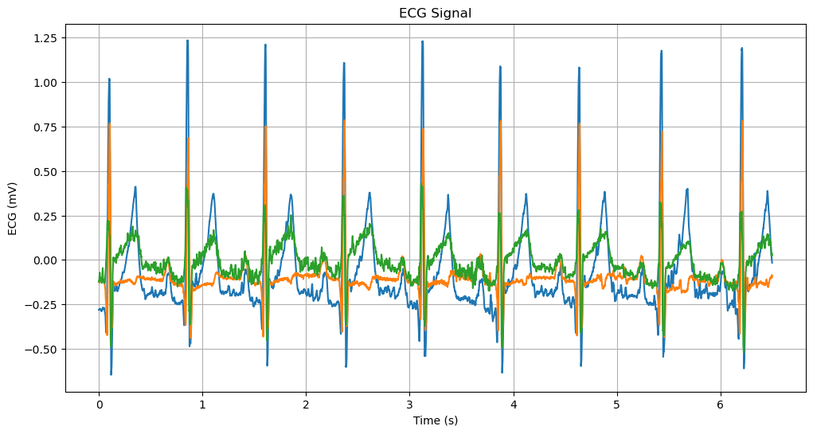

## 5.3. Check the plot

You need to check that the rescaled plot is correct. How will you do this?

By visually inspecting the plot, and answering questions you will write in a new cell, to provide a brief description of why you think it is correct. Commit your changes.

Typical questions to answer:

- Are the number of timeseries correct?
- Are the number of samples correct?
- Are the values in the plot consistent with the expected range of ECG signals?
  - What are the expected values for a normal ECG signal? Find a reference to support your answer.
- Other questions?
  - You get a bonus if you can find other questions to check the plot. Explain why these questions are relevant and how they help to check the plot.

# 6. Improve readability

This is the most crucial aspect of writing data analysis code, as it will save you time and effort in the long run. Take good habits from now on.

## 6.1. Why? To make your code easier to read and understand.

Making your code more readable and understandable is essential, especially for you in the future.

- Are all variables and functions named appropriately?
  - If no, you should rename them to be more descriptive.
    - A variable is named for its purpose/content (e.g., `num_ecg_leads`).
    - A function is named for its action (e.g., `plot_one_ecg_lead`), and its action should be a single, clear task.
  - If yes, you should ask a colleague for feedback, and likely incorporate their suggestions.
- Do you have pieces of code that are the same at different places (e.g., copied from elsewhere)?
  - If yes, you should refactor your code to eliminate duplication. This will make your code more readable and maintainable. The solution is to create a function to replace the duplicated code.
- Do you have long code blocks (more than 20 lines)?
  - If yes, you should consider breaking them up into smaller, more manageable functions.
- Do you have a Markdown cell explaining the **why** you are doing this in the next Python code cell?
  - If no, you should add one to improve the readability and maintainability of your code.
- Do you have comments explaining your code?
  - If no, are you sure that it is because your code is self-explanatory?
  - If yes, you should rethink them, to ensure that they are concise, and helpful (e.g., use docstrings for functions). Maybe you will no longer need a comment if you rename a variable or function?

## 6.2. How? Using Git branches.

In your attempt to improve code readability, you will make mistakes along the way, and that's okay.  
Before starting, use GitHub Desktop to create a **new branch** in your Git repository. In this branch, you will work on your improvements without affecting the already existing codebase.  
Once you are satisfied with your changes, you can merge your improvements back into the main branch (maybe after reviewing them with a colleague... just to be sure).

# 7. Make a plot that resembles what you get with real ECG systems

You have multiple leads (I, II, III) to display. You can create subplots for each lead to mimic the appearance of a real ECG monitor.

Example: https://ecglibrary.com/norm.php

Your mission is to **create a realistic ECG plot** using Matplotlib.

- This is far more complex than the previous exercises...
- For sure, you will need a new branch and you will need several steps of improvements to achieve the desired result.

If you want to get help from a LLM, you need to provide a clear specification of what you need, and the desired outcome. You also need to provide a clear description of a planned architecture of the expected code, so that the LLM can help you implement it.

Below is my suggestion for one possible architecture of your code, to guide your LLM in helping you implement it:

- A function `plot_grid` to plot the grid on the current matplotlib axes with the specified parameters:
  - seconds_per_square : float The time interval for each vertical line in seconds.
  - mV_per_square : float The voltage interval for each horizontal line in millivolts.
  - alpha : float The transparency of the grid lines (0.0 to 1.0).
  - min_time : float The minimum time value for the grid.
  - max_time : float The maximum time value for the grid. min_ecg : float The minimum ECG value for the grid.
  - max_ecg : float The maximum ECG value for the grid.
- A function `plot_ecg_grid` so that a grid is plotted on the current matplotlib axes that matches the classical ECG conventions :
  1. Vertical lines at 0.2s intervals
  2. Horizontal lines at 0.5mV intervals
  3. Lighter lines at 1/5 of the previous intervals
- A function `plot_one_ecg_signal` to plot the ECG signal of one lead on the current matplotlib axes, with the specified parameters:
  - time : array-like The time values for the ECG signal.
  - ecg : array-like The ECG signal values for the specified lead.
  - lead_name : str The name of the ECG lead (e.g., "Lead I").
  - color : str The color of the ECG line.
- A function `plot_one_lead_in_subplots` to make realistic plot one ECG lead on the grid in a subplot, with the specified parameters:
  - subplot : int The subplot index (1, 2, or 3) where the ECG lead will be plotted.
  - time : array-like The time values for the ECG signal.
  - ecg : array-like The ECG signal values for the specified lead.
  - lead_name : str The name of the ECG lead (e.g., "Lead I").
  - color : str The color of the ECG line.
- A function `plot_all_leads_in_subplots` to make realistic plot all ECG leads on the grid in subplots, with the specified parameters:
  - time : array-like The time values for the ECG signal.
  - ecg : array-like The ECG signal values for all leads.
  - lead_names : list of str The names of the ECG leads (e.g., ["Lead I", "Lead II", "Lead III"]).
  - colors : list of str The colors of the ECG lines for each lead.

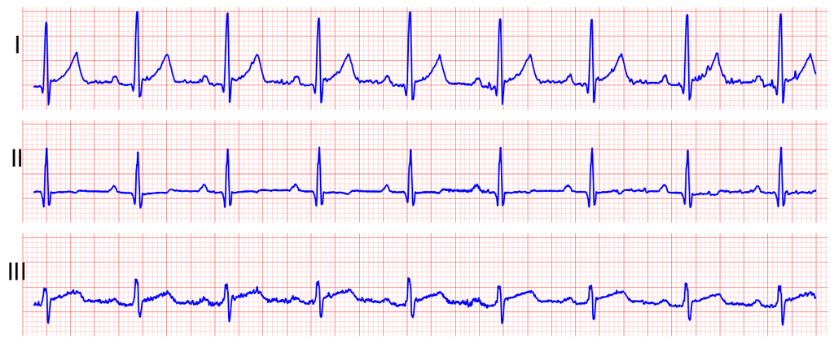